# Analyses et figures de l’expérience 1 - thèse : Répétition, division e l’attention et crédibilité

# Figures produites

Pour terminer, je présente ici les figures produites.

## Scores de mémoire de source en fonction de la liste, de la division de l’attention et de la crédibilité

Note : les barres d’erreur représentent les intervalles de confiance à 95%.

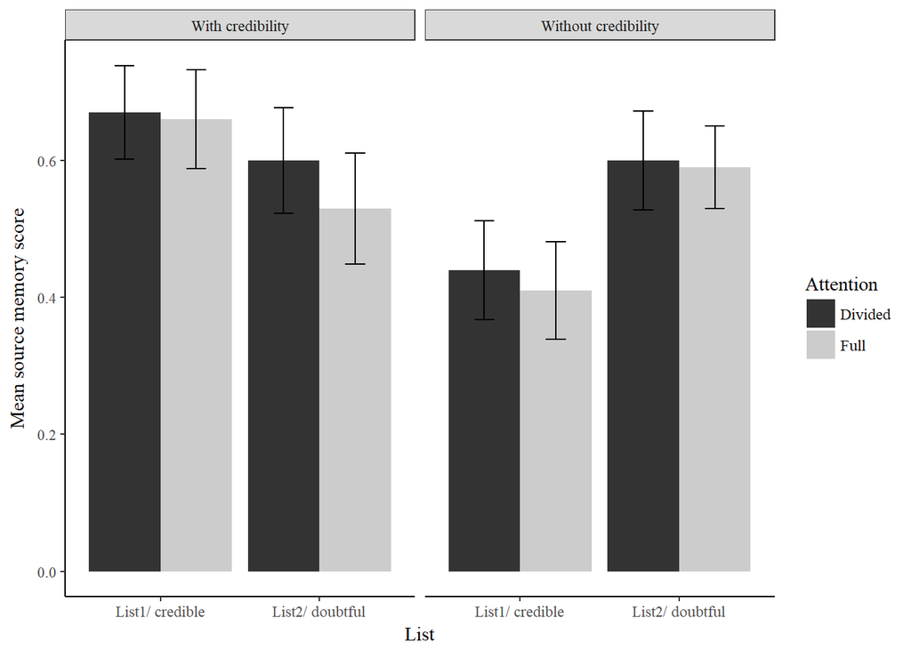

## Score de jugement de vérité en fonction de la liste, de la division de l’attention et de la crédibilité

Note : les barres noires représentent les moyennes et les rectangles de couleur les intervalles de confiance à 95%. La ligne horizontale représente l’absence d’effet de vérité.

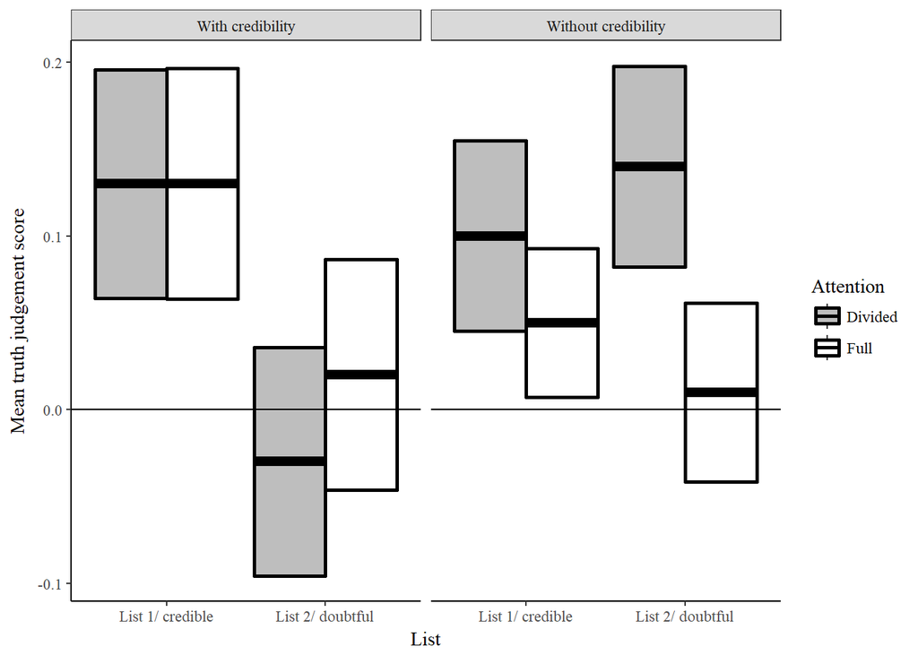

# Modèle mixte généralisé

Afin de fournir un test plus contraignant des hypothèses, un modèle mixte généralisé a été constitué. La source (liste 1/ crédible ; liste 2/ douteux ; nouveau), la division de l’attention et la crédibilité ont été rentrées en facteurs, les réponses dichotomiques au jugement de vérité (vrai; faux) ont été rentrées comme VD, et les énoncés et participants ont été rentrés en tant que variables aléatoires.

```r
#Fit a generalized linear mixed-effects model on dichotomous truth judgement responses according to source (list1/ credible; list/ doubtful; new), credibility and attention. Random effects : participants and statements

model_t_log <- glmer(truth_rating_num ~ enonce_source*manip_attention*manip_cred+(1|ppt)+(1|enonce),family=binomial,data=data_extend,control=glmerControl(optimizer="bobyqa",
                            optCtrl=list(maxfun=2e5)))
summary(model_t_log)
```

```
Generalized linear mixed model fit by maximum likelihood (Laplace
  Approximation) [glmerMod]
 Family: binomial  ( logit )
Formula:
truth_rating_num ~ enonce_source * manip_attention * manip_cred +
    (1 | ppt) + (1 | enonce)
   Data: data_extend
Control:
glmerControl(optimizer = "bobyqa", optCtrl = list(maxfun = 2e+05))

     AIC      BIC   logLik deviance df.resid
 14123.4  14195.9  -7051.7  14103.4    10406

Scaled residuals:
    Min      1Q  Median      3Q     Max
-1.9467 -0.9989  0.6602  0.8999  1.6759

Random effects:
 Groups Name        Variance Std.Dev.
 ppt    (Intercept) 0.07093  0.2663
 enonce (Intercept) 0.14400  0.3795
Number of obs: 10416, groups:  ppt, 186; enonce, 129

Fixed effects:
                                              Estimate Std. Error z value
(Intercept)                                   0.402074   0.127855   3.145
enonce_source                                -0.136348   0.048621  -2.804
manip_attentionnd                            -0.021999   0.174854  -0.126
manip_crednc                                  0.427042   0.176621   2.418
enonce_source:manip_attentionnd               0.009856   0.069113   0.143
enonce_source:manip_crednc                   -0.107998   0.069659  -1.550
manip_attentionnd:manip_crednc               -0.442858   0.248584  -1.782
enonce_source:manip_attentionnd:manip_crednc  0.131871   0.098133   1.344
                                             Pr(>|z|)
(Intercept)                                   0.00166 **
enonce_source                                 0.00504 **
manip_attentionnd                             0.89988
manip_crednc                                  0.01561 *
enonce_source:manip_attentionnd               0.88660
enonce_source:manip_crednc                    0.12105
manip_attentionnd:manip_crednc                0.07483 .
enonce_source:manip_attentionnd:manip_crednc  0.17901
---
Signif. codes:  0 '***' 0.001 '**' 0.01 '*' 0.05 '.' 0.1 ' ' 1

Correlation of Fixed Effects:
               (Intr) ennc_s mnp_tt mnp_cr ennc_src:mnp_t ennc_src:mnp_c
enonce_sorc    -0.857
mnp_ttntnnd    -0.677  0.626
manip_crdnc    -0.670  0.620  0.489
ennc_src:mnp_t  0.603 -0.703 -0.891 -0.436
ennc_src:mnp_c  0.598 -0.697 -0.437 -0.893  0.490
mnp_ttntn:_     0.476 -0.440 -0.703 -0.710  0.627          0.634
ennc_sr:_:_    -0.424  0.495  0.627  0.633 -0.704         -0.709
               mnp_:_
enonce_sorc
mnp_ttntnnd
manip_crdnc
ennc_src:mnp_t
ennc_src:mnp_c
mnp_ttntn:_
ennc_sr:_:_    -0.892
```

```r
anova(model_t_log)
```

```
Analysis of Variance Table
                                         Df Sum Sq Mean Sq F value
enonce_source                             1 38.387  38.387 38.3872
manip_attention                           1  1.561   1.561  1.5611
manip_cred                                1  3.839   3.839  3.8392
enonce_source:manip_attention             1  2.322   2.322  2.3217
enonce_source:manip_cred                  1  0.719   0.719  0.7190
manip_attention:manip_cred                1  1.672   1.672  1.6722
enonce_source:manip_attention:manip_cred  1  1.834   1.834  1.8340
```